# Assignment 1: dplyr and UNC departments

STOR 390

Universities are typicall opaque, bureaucratic institutions. Many public schools such as the University of North Carolina system make [data about university employees publically](http://www.newsobserver.com/news/databases/public-salaries/) available. Using this dataset what can we learn about the dynamics of the university system?

## dplyr

To download the .Rmd file for this assignment go to the [github repo](https://github.com/idc9/stor390/tree/master/assignments/unc_depts), right click **und_depts.Rmd** and select *save link as*.

The best way to to learn the dplyr package is to just use it a lot. Read through the following dplyr tutorial the complete quetions in this .Rmd document. I suggest doing the coding in an R script then putting the answers into this documents.

- [dplyr flights vignettes](https://cran.rstudio.com/web/packages/dplyr/vignettes/introduction.html)
- chapter 5 ([data transformation](http://r4ds.had.co.nz/transform.html)) from r4ds

## Instructions

- please finish these questions by Tuesday, Jan 24. More questions will added then.
- use the `dplyr` functions to answer the following questions (base R will not be given credit)
- submit just the .Rmd file to Sakai
- pay careful attention to the questions
- **return** something means just print it out. Similarly for questions **What is …** just print out the answer

Q: Return the sum of the first 10 positive integers?

Q: What is the sum of the first 10 positive integers?

```r
sum(1:10)
```

```
## [1] 55
```

- **create** or **save** means save a variable

Create a variable `x` with the sum of the first 10 positive integers.

```r
x <- sum(1:10)
```

# The data

First download the data set from Ryan Thornburg’s website (it is also on stor390’s github repo). You may want to set `cache=TRUE` for this chunk so you don’t have to download the data set everytime you run the script.

```r
library(tidyverse)

# Load the UNC departments data
data <- read_csv(url("http://ryanthornburg.com/wp-content/uploads/2015/05/UNC_Salares_NandO_2015-05-06.csv"))
```

Take a first look at the data

```r
colnames(data)
```

```
##  [1] "name"     "campus"   "dept"     "position" "exempt2"  "employed"
##  [7] "hiredate" "fte"      "status"   "stservyr" "statesal" "nonstsal"
## [13] "totalsal" "age"
```

```r
str(data)
```

```
## Classes 'tbl_df', 'tbl' and 'data.frame':    12287 obs. of  14 variables:
##  $ name    : chr  "AARON, NANCY G" "ABARBANELL, JEFFERY S" "ABARE, BETSY" "ABATE, AARON B" ...
##  $ campus  : chr  "UNC-CH" "UNC-CH" "UNC-CH" "UNC-CH" ...
##  $ dept    : chr  "Romance Languages" "Kenan-Flagler Business School" "Institute of Marine Sciences" "Medicine Administration" ...
##  $ position: chr  "Senior Lecturer" "Associate Professor" "Research Technician" "Accounting Technician" ...
##  $ exempt2 : chr  "Exempt" "Exempt" "Subject to State Personnel Act" "Subject to State Personnel Act" ...
##  $ employed: int  9 9 12 12 12 12 12 12 12 12 ...
##  $ hiredate: int  20030701 19990101 20110912 20090420 20120103 20051003 19960923 20130401 19870101 20120702 ...
##  $ fte     : num  1 1 1 1 1 1 1 1 1 1 ...
##  $ status  : chr  "Fixed-Term" "Continuing" "Permanent" "Permanent" ...
##  $ stservyr: int  11 17 3 5 2 15 34 11 27 2 ...
##  $ statesal: int  46350 173000 0 0 41696 56588 41707 0 0 0 ...
##  $ nonstsal: int  0 0 38170 50070 0 4412 0 80227 55803 32889 ...
##  $ totalsal: int  46350 173000 38170 50070 41696 61000 41707 80227 55803 32889 ...
##  $ age     : int  55 57 54 29 35 41 62 36 64 26 ...
##  - attr(*, "spec")=List of 2
##   ..$ cols   :List of 14
##   .. ..$ name    : list()
##   .. .. ..- attr(*, "class")= chr  "collector_character" "collector"
##   .. ..$ campus  : list()
##   .. .. ..- attr(*, "class")= chr  "collector_character" "collector"
##   .. ..$ dept    : list()
##   .. .. ..- attr(*, "class")= chr  "collector_character" "collector"
##   .. ..$ position: list()
##   .. .. ..- attr(*, "class")= chr  "collector_character" "collector"
##   .. ..$ exempt2 : list()
##   .. .. ..- attr(*, "class")= chr  "collector_character" "collector"
##   .. ..$ employed: list()
##   .. .. ..- attr(*, "class")= chr  "collector_integer" "collector"
##   .. ..$ hiredate: list()
##   .. .. ..- attr(*, "class")= chr  "collector_integer" "collector"
##   .. ..$ fte     : list()
##   .. .. ..- attr(*, "class")= chr  "collector_double" "collector"
##   .. ..$ status  : list()
##   .. .. ..- attr(*, "class")= chr  "collector_character" "collector"
##   .. ..$ stservyr: list()
##   .. .. ..- attr(*, "class")= chr  "collector_integer" "collector"
##   .. ..$ statesal: list()
##   .. .. ..- attr(*, "class")= chr  "collector_integer" "collector"
##   .. ..$ nonstsal: list()
##   .. .. ..- attr(*, "class")= chr  "collector_integer" "collector"
##   .. ..$ totalsal: list()
##   .. .. ..- attr(*, "class")= chr  "collector_integer" "collector"
##   .. ..$ age     : list()
##   .. .. ..- attr(*, "class")= chr  "collector_integer" "collector"
##   ..$ default: list()
##   .. ..- attr(*, "class")= chr  "collector_guess" "collector"
##   ..- attr(*, "class")= chr "col_spec"
```

```r
head(data)
```

```
## # A tibble: 6 × 14
##                        name campus                          dept
##                       <chr>  <chr>                         <chr>
## 1            AARON, NANCY G UNC-CH             Romance Languages
## 2     ABARBANELL, JEFFERY S UNC-CH Kenan-Flagler Business School
## 3              ABARE, BETSY UNC-CH  Institute of Marine Sciences
## 4            ABATE, AARON B UNC-CH       Medicine Administration
## 5        ABATEMARCO, JODI M UNC-CH           School of Education
## 6 ABBOTT-LUNSFORD, SHELBY L UNC-CH       Medicine Administration
## # ... with 11 more variables: position <chr>, exempt2 <chr>,
## #   employed <int>, hiredate <int>, fte <dbl>, status <chr>,
## #   stservyr <int>, statesal <int>, nonstsal <int>, totalsal <int>,
## #   age <int>
```

# Assignment

## Quesetion 1

Return a data frame with columns: name, dept, age,totalsal

```r
data[,c("name", "dept", "age", "totalsal")]
```

```
## # A tibble: 12,287 × 4
##                         name                          dept   age totalsal
##                        <chr>                         <chr> <int>    <int>
## 1             AARON, NANCY G             Romance Languages    55    46350
## 2      ABARBANELL, JEFFERY S Kenan-Flagler Business School    57   173000
## 3               ABARE, BETSY  Institute of Marine Sciences    54    38170
## 4             ABATE, AARON B       Medicine Administration    29    50070
## 5         ABATEMARCO, JODI M           School of Education    35    41696
## 6  ABBOTT-LUNSFORD, SHELBY L       Medicine Administration    41    61000
## 7         ABBOTTS, WILLIAM C                       Biology    62    41707
## 8          ABDOULAYI, SARA M    Carolina Population Center    36    80227
## 9            ABDULLAH, LUBNA    Cys Fibrosis/Pulmonary Res    64    55803
## 10                ABE, PAIGE         Housing Res Education    26    32889
## # ... with 12,277 more rows
```

Return a data frame with columns: statesal, nonstsal,totalsal using one of the `select_helpers` functions

```r
select(data, statesal, nonstsal, totalsal)
```

```
## # A tibble: 12,287 × 3
##    statesal nonstsal totalsal
##       <int>    <int>    <int>
## 1     46350        0    46350
## 2    173000        0   173000
## 3         0    38170    38170
## 4         0    50070    50070
## 5     41696        0    41696
## 6     56588     4412    61000
## 7     41707        0    41707
## 8         0    80227    80227
## 9         0    55803    55803
## 10        0    32889    32889
## # ... with 12,277 more rows
```

## Quesetion 2

Rename the `fte` column to `fulltime`. Make sure this change is saved (i.e. `data <- ...`).

```r
data <- rename(data, fulltime = fte)
```

## Quesetion 3

What is the mean salary in the Neurosurgery department?

```r
mean(filter(data, dept == "Neurosurgery")$totalsal)
```

```
## [1] 380058.1
```

Return a data frame with employee’s in the Neurosurgery department making more than $500,000. Why might these professors be so well paid?

```r
filter(data, dept == "Neurosurgery" & totalsal > 500000)
```

```
## # A tibble: 6 × 14
##                    name campus         dept                     position
##                   <chr>  <chr>        <chr>                        <chr>
## 1    CAMPBELL, DENNIS M UNC-CH Neurosurgery  Adjunct Assistant Professor
## 2       CARSON, LARRY V UNC-CH Neurosurgery           Clinical Professor
## 3      EWEND, MATTHEW G UNC-CH Neurosurgery                     DIRECTOR
## 4     JAUFMANN, BRUCE P UNC-CH Neurosurgery Clinical Associate Professor
## 5 KILPATRICK, MICHAUX R UNC-CH Neurosurgery Clinical Assistant Professor
## 6        WADON, CAROL M UNC-CH Neurosurgery Clinical Associate Professor
## # ... with 10 more variables: exempt2 <chr>, employed <int>,
## #   hiredate <int>, fulltime <dbl>, status <chr>, stservyr <int>,
## #   statesal <int>, nonstsal <int>, totalsal <int>, age <int>
```

## Quesetion 4

What is the total amount that full time Dermatology employees get paid?

```r
filter(data, dept == "Dermatology" & fulltime == 1)
```

```
## # A tibble: 35 × 14
##                 name campus        dept                          position
##                <chr>  <chr>       <chr>                             <chr>
## 1    BECKHAM, EMMA M UNC-CH Dermatology Assoc Chair for Admin/Dermatology
## 2  BURKHART, CRAIG N UNC-CH Dermatology      Clinical Associate Professor
## 3    CARSON, CRAIG C UNC-CH Dermatology              Postdoctoral Trainee
## 4  CHEEK, KIMBERLY B UNC-CH Dermatology          Admin Support Specialist
## 5   CLAPP, MELINDA L UNC-CH Dermatology                    HR Coordinator
## 6    COLLINS, RYAN M UNC-CH Dermatology               Research Technician
## 7  COOPER, HEATHER S UNC-CH Dermatology   Medical Laboratory Technologist
## 8   CREED, CYNTHIA C UNC-CH Dermatology          Admin. Support Associate
## 9    CULTON, DONNA A UNC-CH Dermatology               Clinical Instructor
## 10      DIAZ, LUIS A UNC-CH Dermatology                          DIRECTOR
## # ... with 25 more rows, and 10 more variables: exempt2 <chr>,
## #   employed <int>, hiredate <int>, fulltime <dbl>, status <chr>,
## #   stservyr <int>, statesal <int>, nonstsal <int>, totalsal <int>,
## #   age <int>
```

## Quesetion 5

Create a data frame called radio_dept whose rows are the employees from the Radiology department.

- include only the followig columns: name, position, age, nonstsal, salary.
- order the employees by salary

First without chaining

```r
radio_dept <- filter(data, dept == "Radiology")
radio_dept <- select(radio_dept, name, position, age, nonstsal, totalsal)
radio_dept <- arrange(radio_dept, totalsal)
radio_dept
```

```
## # A tibble: 88 × 5
##                   name                         position   age nonstsal
##                  <chr>                            <chr> <int>    <int>
## 1     HOOTS, TIFFANY N   Social/Clinical Research Asst.    31    36360
## 2  FISCHER, MICHELLE C         Admin. Support Associate    25    37142
## 3   BIRDSONG, LAURIE B Public Communications Specialist    40    37681
## 4   PENDER, JENNIFER L            Accounting Technician    39    37690
## 5       BARBAL, ISABEL         Admin. Support Associate    57    40061
## 6    MELVILLE, WILMA C      Administrative Secretary II    58    41789
## 7     HARTMAN, TERRY S   Social/Clinical Research Asst.    26    42168
## 8  BOOMHOWER, JEREMY D         Admin. Support Associate    38    42593
## 9   CARVER, VIRGINIA B         Admin. Support Associate    39    42593
## 10     HAUSER, JASON M         Admin. Support Associate    41    42593
## # ... with 78 more rows, and 1 more variables: totalsal <int>
```

Next with chaining

```r
radio_dept <- arrange(
  select(
    filter(data, dept == "Radiology"), name, position, age, nonstsal, totalsal), totalsal)
radio_dept
```

```
## # A tibble: 88 × 5
##                   name                         position   age nonstsal
##                  <chr>                            <chr> <int>    <int>
## 1     HOOTS, TIFFANY N   Social/Clinical Research Asst.    31    36360
## 2  FISCHER, MICHELLE C         Admin. Support Associate    25    37142
## 3   BIRDSONG, LAURIE B Public Communications Specialist    40    37681
## 4   PENDER, JENNIFER L            Accounting Technician    39    37690
## 5       BARBAL, ISABEL         Admin. Support Associate    57    40061
## 6    MELVILLE, WILMA C      Administrative Secretary II    58    41789
## 7     HARTMAN, TERRY S   Social/Clinical Research Asst.    26    42168
## 8  BOOMHOWER, JEREMY D         Admin. Support Associate    38    42593
## 9   CARVER, VIRGINIA B         Admin. Support Associate    39    42593
## 10     HAUSER, JASON M         Admin. Support Associate    41    42593
## # ... with 78 more rows, and 1 more variables: totalsal <int>
```

Make a histogram of Radiology salaries

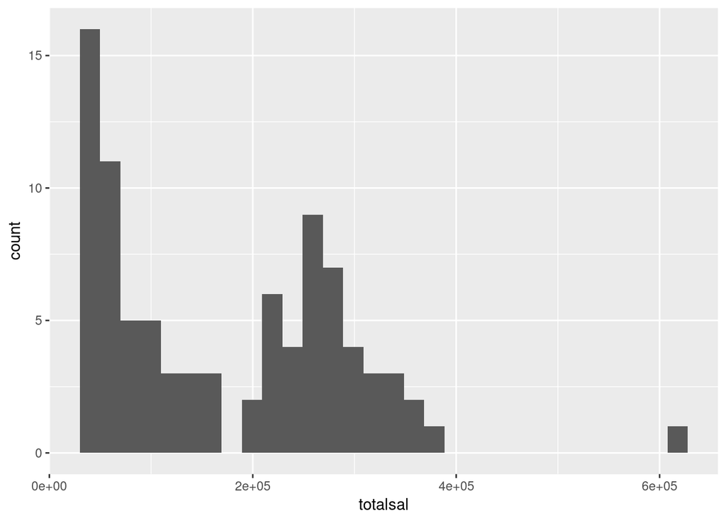

```r
ggplot(data = select(radio_dept, totalsal),
       mapping = aes(x = totalsal)) + geom_histogram()
```

## Question 6

Use faceting to make totalsal histograms for Radiation Oncology, Radiology, Pediatrics, and Orthopaedics departments.

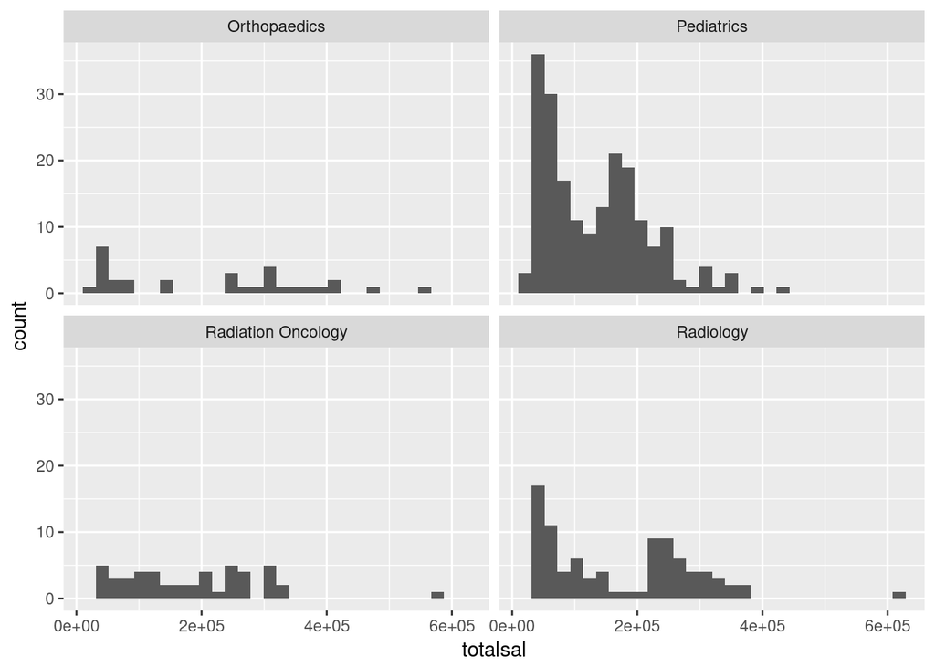

```r
ggplot(data = filter(data,
                     dept == "Radiation Oncology" |
                       dept == "Radiology" |
                       dept == "Pediatrics" |
                       dept == "Orthopaedics"),
       mapping = aes(x = totalsal)) +
  geom_histogram() +
  facet_wrap(~dept)
```

Use faceting to make plot age vs. totalsal for the same four departments and color points position.

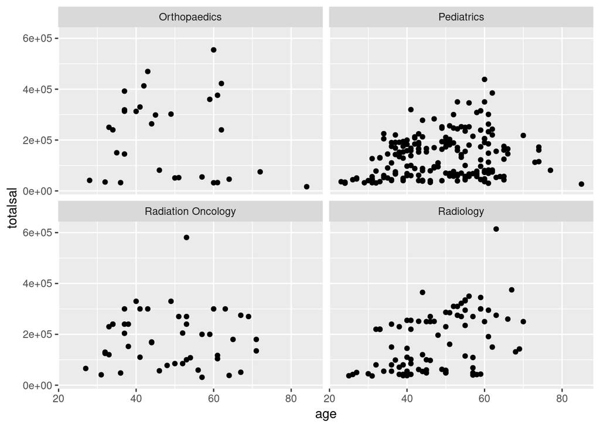

```r
ggplot(data = filter(data,
                     dept == "Radiation Oncology" |
                       dept == "Radiology" |
                       dept == "Pediatrics" |
                       dept == "Orthopaedics"),
       mapping = aes(x = age, y = totalsal)) +
  geom_point() +
  facet_wrap(~dept)
```

## Question 7

Create a data frame called `dept_summary` whose rows are the departments and whose columns are: department size, mean department salary, median department salary, and maximum salary.

```r
dept_summary <- group_by(data, dept)
dept_summary <- summarize(dept_summary,
                          dept_size = n(),
                          mean_sal = mean(totalsal, na.rm = TRUE),
                          med_sal = median(totalsal, na.rm = TRUE),
                          max_sal = max(totalsal))
head(dept_summary)
```

```
## # A tibble: 6 × 5
##                             dept dept_size mean_sal med_sal max_sal
##                            <chr>     <int>    <dbl>   <dbl>   <int>
## 1              Academic Advising        42 49984.95   45000  109625
## 2 Acad Sup Prog Student-Athletes        15 55798.33   50600  115000
## 3            Accounting Services        17 57417.24   59342  103306
## 4             Ackland Art Museum        19 51543.47   41000  140050
## 5                     Admissions        46 57487.20   49000  195700
## 6  African, Afri-Amer & Diaspora        23 65169.96   68000  135608
```

```r
summary(dept_summary)
```

```
##      dept             dept_size         mean_sal         med_sal
##  Length:304         Min.   :  1.00   Min.   : 18296   Min.   : 10000
##  Class :character   1st Qu.:  6.00   1st Qu.: 51906   1st Qu.: 46929
##  Mode  :character   Median : 18.00   Median : 65140   Median : 59100
##                     Mean   : 40.42   Mean   : 73912   Mean   : 66413
##                     3rd Qu.: 47.25   3rd Qu.: 86614   3rd Qu.: 73970
##                     Max.   :512.00   Max.   :380058   Max.   :395550
##     max_sal
##  Min.   : 34540
##  1st Qu.: 85349
##  Median :133350
##  Mean   :180239
##  3rd Qu.:230625
##  Max.   :819069
```

```r
colnames(dept_summary)
```

```
## [1] "dept"      "dept_size" "mean_sal"  "med_sal"   "max_sal"
```

Order the departments by highest mean salary and print the 10 highest paid departments.

```r
head(arrange(dept_summary, desc(mean_sal)), 10)
```

```
## # A tibble: 10 × 5
##                        dept dept_size mean_sal med_sal max_sal
##                       <chr>     <int>    <dbl>   <dbl>   <int>
## 1              Neurosurgery        17 380058.1  395550  621722
## 2                   Provost         4 273790.0  240080  445000
## 3                   Urology        20 216291.1  237500  520569
## 4              Orthopaedics        31 216205.4  240000  554559
## 5                   Surgery       121 201917.4  176083  677310
## 6            Anesthesiology        94 187177.4  222645  620040
## 7        Radiation Oncology        47 183044.7  180000  580923
## 8           Carolina Counts         1 182160.0  182160  182160
## 9                 Radiology        88 172053.1  149984  614176
## 10 Office of the Chancellor        13 164746.7  135000  520000
```

Order the departments by highest median salary and print the 10 highest paid departments.

```r
head(arrange(dept_summary, desc(med_sal)), 10)
```

```
## # A tibble: 10 × 5
##                        dept dept_size mean_sal med_sal max_sal
##                       <chr>     <int>    <dbl>   <dbl>   <int>
## 1              Neurosurgery        17 380058.1  395550  621722
## 2                   Provost         4 273790.0  240080  445000
## 3              Orthopaedics        31 216205.4  240000  554559
## 4                   Urology        20 216291.1  237500  520569
## 5            Anesthesiology        94 187177.4  222645  620040
## 6           Carolina Counts         1 182160.0  182160  182160
## 7        Radiation Oncology        47 183044.7  180000  580923
## 8                   Surgery       121 201917.4  176083  677310
## 9  University Ombuds Office         3 128425.3  157127  164985
## 10    Ath Basketball Office        10 159349.7  150000  371402
```

Why do these lists differ? If you were asked for the top 10 best paid departments at UNC which summary would you choose and why?

They differ because mean is the average and median is the middle of a group. Median salary will offer the best representation of pay rates of departments. The mean is more prone to being skewed and can offer a misrepresentation of salary data. The median, however, simply states half of employees make more and half less than this value, which makes it a more accurate representation of a typical salary.

## Question 8

How many departments have at least 10 employees?

```r
nrow(filter(summarize(group_by(data, dept), emp = n()), emp >= 10))
```

```
## [1] 194
```

## Question 9

Which department hired the most people in 2010? Hint: you probably have to modify `hiredate`.

```r
head(arrange(summarize(group_by(filter(data, hiredate > 20099999 & hiredate < 20110000), dept), count = n()), desc(count)), 1)$dept
```

```
## [1] "Medicine"
```

## Question 10

Make a list of all the department names and sort this list alphabetically. What is the 42nd department in this list?

```r
slice(arrange(distinct(data, dept), dept), 42)$dept
```

```
## [1] "Ath Physical Development"
```

## Question 11

Plot number of people hired by the CS dept per year vs. year

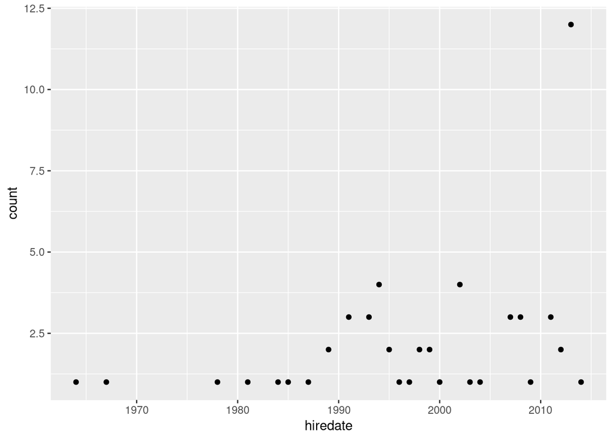

```r
cs_hires <- summarize(
  group_by(
    mutate(
      select(
        filter(data, dept == "Computer Science"),
        hiredate),
      hiredate = as.integer(hiredate / 10000)),
    hiredate),
  count = n())
for (year in min(cs_hires$hiredate):max(cs_hires$hiredate)) {
  if (!(year %in% cs_hires$hiredate)) {
    add_row(cs_hires, hiredate = year, count = 0)
  }
}

ggplot(data = cs_hires, mapping = aes(x = hiredate, y = count)) +
         geom_point()
```

Now add STOR, Math, Biostatistics, SILS and Physics to the above plot

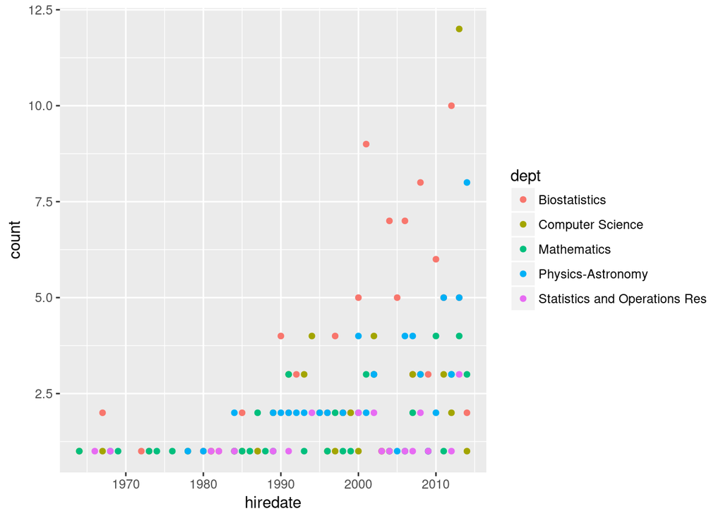

```r
more_hires <- summarize(
  group_by(
    mutate(
      select(
        filter(data, dept == "Computer Science" | dept == "SILS" | dept == "Mathematics" | dept == "Statistics and Operations Res" | dept == "Biostatistics" | dept == "Physics-Astronomy"),
        dept, hiredate),
      hiredate = as.integer(hiredate / 10000), dept = dept),
    hiredate, dept),
  count = n())

ggplot(data = more_hires, mapping = aes(x = hiredate, y = count, color = dept)) +
         geom_point()
```

# Open question

Examine the relationship between age and salary at UNC. You can interpret this however you like e.g.

- age can mean number of years employed at the university
- compare and contrast different departments

Requirements

- hand in a separate .Rmd document
  - load the data with read_csv(url(…)) like this script
- make 3 figures
  - a figure can be a visualization, print out of a data frame that you can created, the results of a statistical model/test (e.g. linear regression)
- display all code used
  - code should be commented
  - if you have a lot of functions you can put them in a separate .R script
- describe each figure
  - what is the figure (figure blah is a plot of foo vs. bar)
  - what is the upshot of the figure (figure blah shows that there is a strong relationship between foo and bar)
- write an explanation of your findings
  - a couple paragraphs
  - use proper grammar
  - your findings should be clear

# hints

- Read through the first dplyr tutorial. Every question can be answered using: filter, arrange, select, mutate, summarise and group_by functions.
- here are two more dplyr tutorials: https://rpubs.com/justmarkham/dplyr-tutorial and https://www.coursera.org/learn/data-cleaning/home/week/3
- fte means full time employee